# Data624_Project1

Vijaya Cherukuri

10/20/2020

## Project 1 - This Project has 3 Parts - 2 required and 1 bonus

```r
#Load Required Libraries
suppressMessages(suppressWarnings(library(fpp2)))
suppressMessages(suppressWarnings(library(ggplot2)))
suppressMessages(suppressWarnings(library(dplyr)))
suppressMessages(suppressWarnings(library(tidyverse)))
suppressMessages(suppressWarnings(library(scales)))
suppressMessages(suppressWarnings(library(forecast)))
suppressMessages(suppressWarnings(library(lubridate)))
suppressMessages(suppressWarnings(library(readxl)))
suppressMessages(suppressWarnings(library(tidyr)))
suppressMessages(suppressWarnings(library(plotly)))
```

### Part A – ATM Forecast :

### In part A, I want you to forecast how much cash is taken out of 4 different ATM machines for May 2010. The data is given in a single file. The variable ‘Cash’ is provided in hundreds of dollars, other than that it is straight forward. I am being somewhat ambiguous on purpose to make this have a little more business feeling. Explain and demonstrate your process, techniques used and not used, and your actual forecast. I am giving you data via an excel file, please provide your written report on your findings, visuals, discussion and your R code via an RPubs link along with the actual.rmd file Also please submit the forecast which you will put in an Excel readable file.

#### Loading Data and verifying

```r
df <- readxl::read_excel('ATM624Data.xlsx') %>%
      drop_na() %>%
      spread(ATM, Cash) %>%
      mutate(DATE = as.Date(DATE, origin='1899-12-30'))


atm <- ts(df %>% select(-DATE))

atm %>%
  summary()
```

```
##       ATM1             ATM2             ATM3              ATM4
##  Min.   :  1.00   Min.   :  0.00   Min.   : 0.0000   Min.   :    1.563
##  1st Qu.: 73.00   1st Qu.: 25.50   1st Qu.: 0.0000   1st Qu.:  124.334
##  Median : 91.00   Median : 67.00   Median : 0.0000   Median :  403.839
##  Mean   : 83.89   Mean   : 62.58   Mean   : 0.7206   Mean   :  474.043
##  3rd Qu.:108.00   3rd Qu.: 93.00   3rd Qu.: 0.0000   3rd Qu.:  704.507
##  Max.   :180.00   Max.   :147.00   Max.   :96.0000   Max.   :10919.762
##  NA's   :3        NA's   :2
```

#### Analyze the data and look for outliers

```r
head(atm)
```

```
## Time Series:
## Start = 1
## End = 6
## Frequency = 1
##   ATM1 ATM2 ATM3      ATM4
## 1   96  107    0 776.99342
## 2   82   89    0 524.41796
## 3   85   90    0 792.81136
## 4   90   55    0 908.23846
## 5   99   79    0  52.83210
## 6   88   19    0  52.20845
```

#### Plot to display Withdrawls

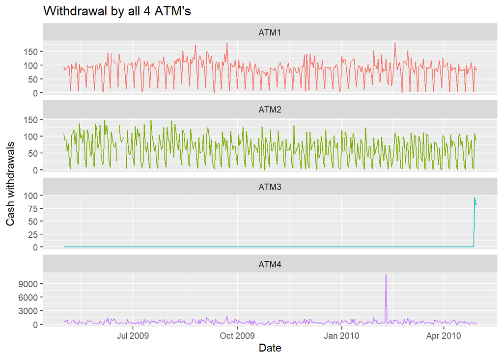

```r
df %>% gather(atm, Cash, -DATE) %>%
  ggplot(aes(x = DATE, y = Cash, col = atm)) +
  geom_line(show.legend = FALSE) +
  facet_wrap(~ atm, ncol = 1, scales = "free_y") +
  labs(title = "Withdrawal by all 4 ATM's", x = "Date") +
  scale_y_continuous("Cash withdrawals")
```

> Based on above graph we can observe that Atm1 and Atm2 has seasonal patterns. Atm3 has only last 3 days values and Atm4 has an outlier.

#### Data Wrangling

```r
atm_1 <- atm[, "ATM1"]
atm_2 <- atm[, "ATM2"]
atm_3 <- atm[, "ATM3"]
atm_4 <- atm[, "ATM4"]
```

#### Use frequency to get weekly measure

```r
atm1 <- ts(atm_1, frequency = 7)
atm2 <- ts(atm_2, frequency = 7)
atm3 <- ts(atm_3, frequency = 7)
atm4 <- ts(atm_4, frequency = 7)
```

#### Create Time Series for ATM1, ATM2, ATM3 and ATM4

#### For ATM1

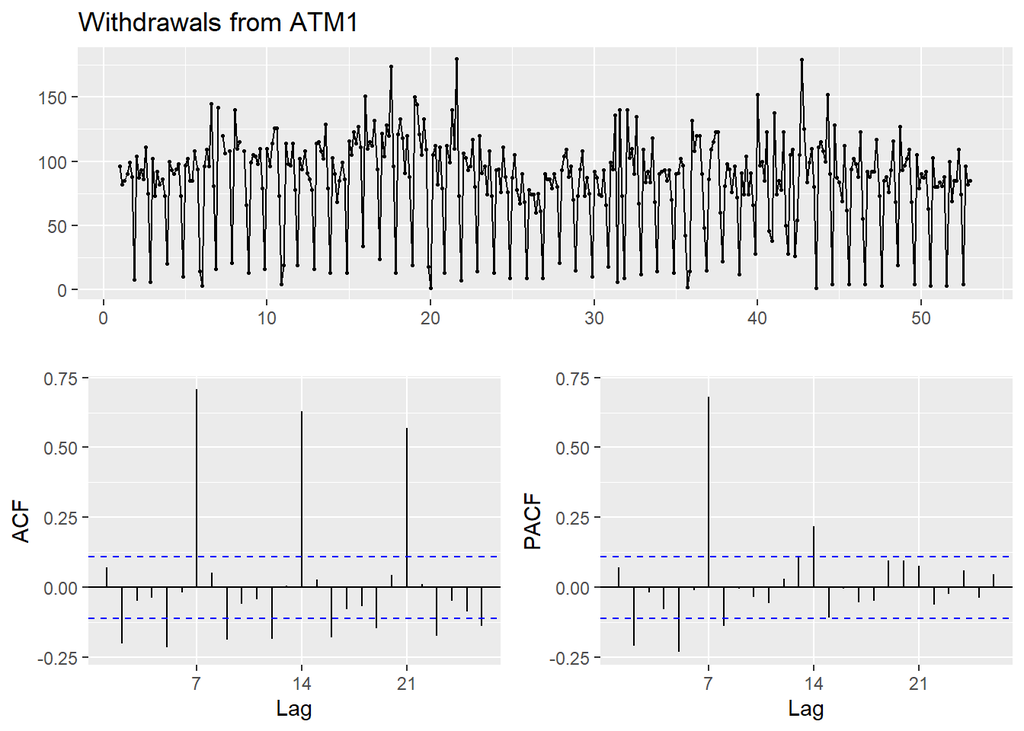

```r
ggtsdisplay(atm1, main = "Withdrawals from ATM1")
```

#### For ATM2

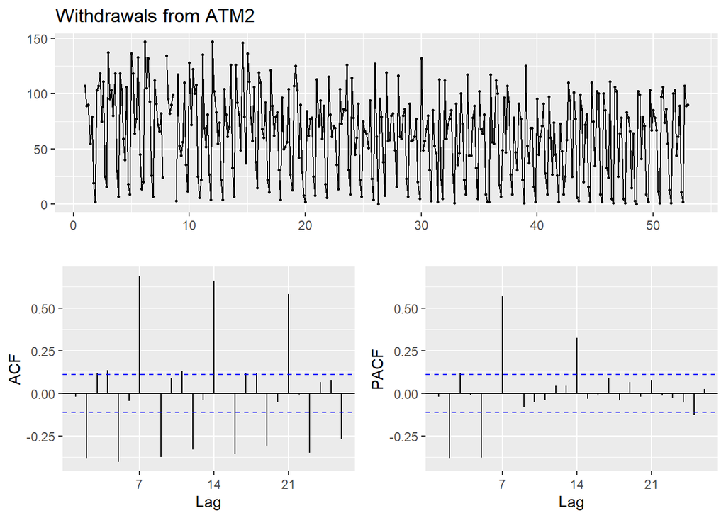

```r
ggtsdisplay(atm2, main = "Withdrawals from ATM2")
```

#### For ATM3

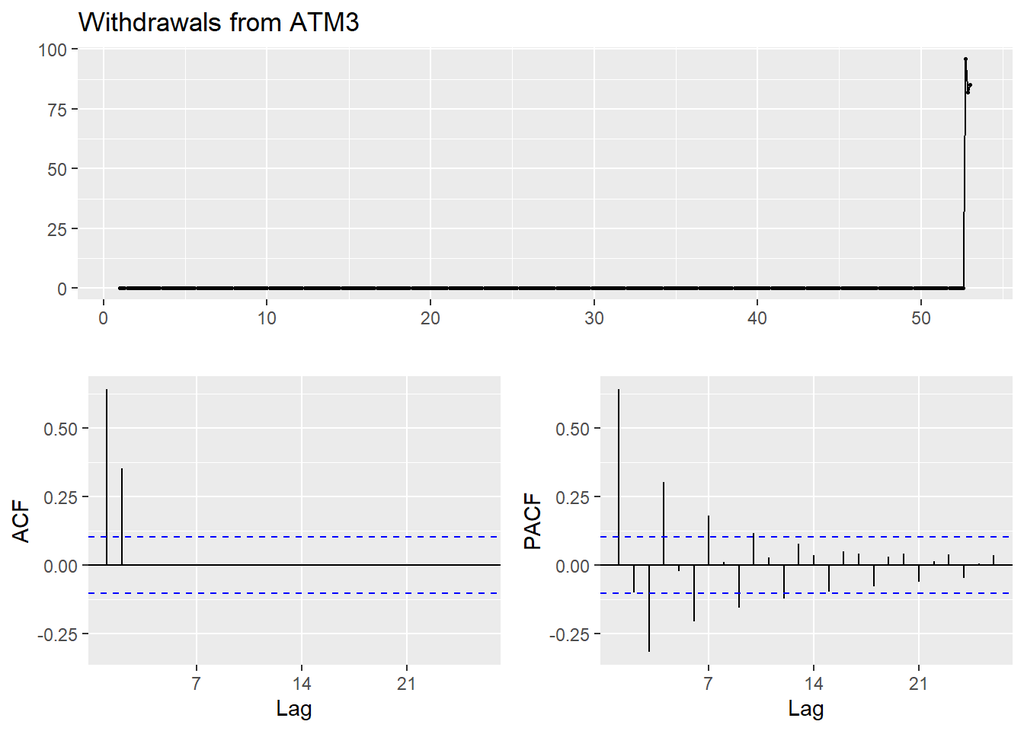

```r
ggtsdisplay(atm3, main = "Withdrawals from ATM3")
```

#### For ATM4

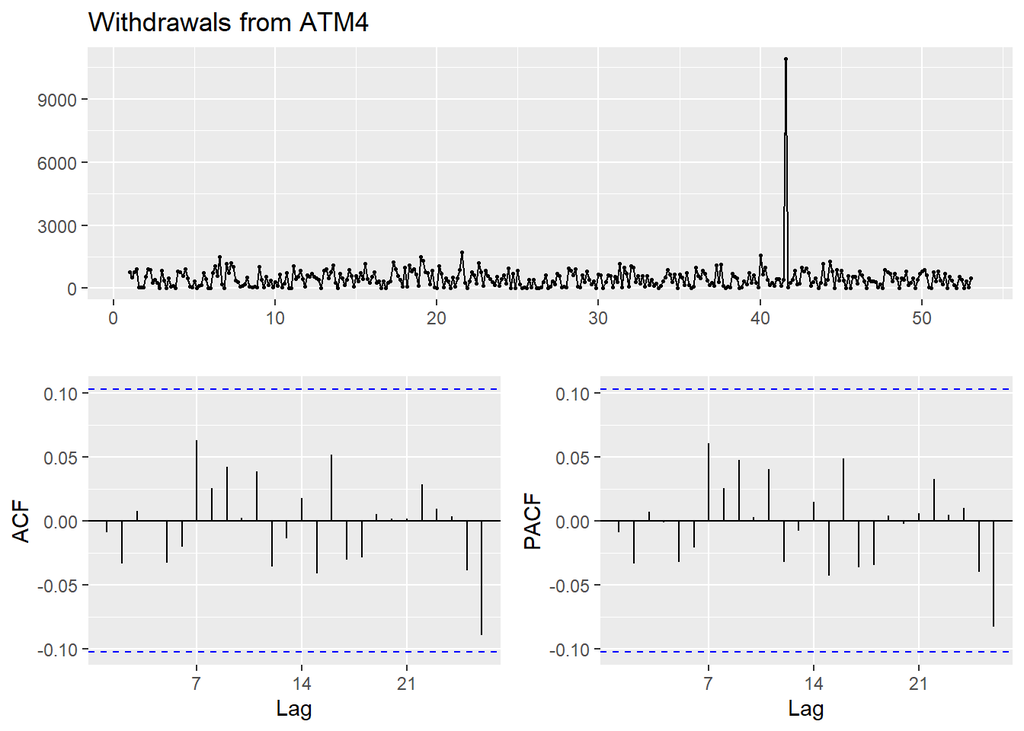

```r
ggtsdisplay(atm4, main = "Withdrawals from ATM4")
```

#### Model

#### Create model for 1st ATM

#### Use ETS

```r
fc_atm1_ets <- ets(atm1)
```

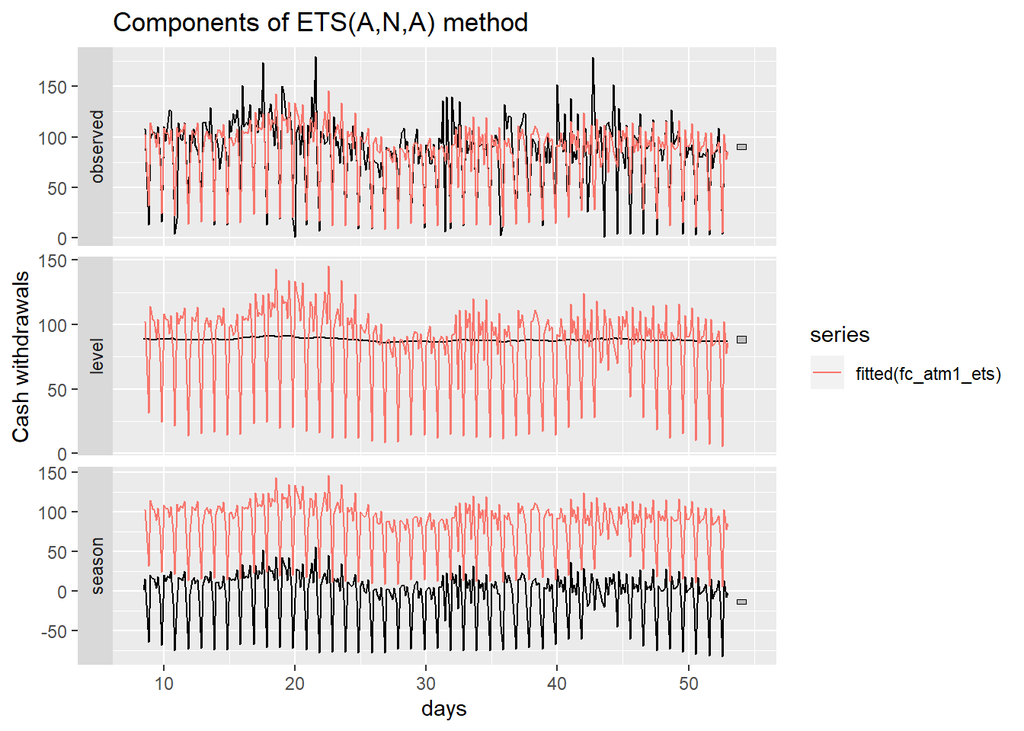

```r
autoplot(fc_atm1_ets) +
  autolayer(fitted(fc_atm1_ets)) +
  ylab("Cash withdrawals") + xlab("days")
```

#### Check summary of ets method applied to ATM1

```r
summary(fc_atm1_ets)
```

```
## ETS(A,N,A)
##
## Call:
##  ets(y = atm1)
##
##   Smoothing parameters:
##     alpha = 0.01
##     gamma = 0.3803
##
##   Initial states:
##     l = 88.8307
##     s = 1.0742 14.6617 15.5558 25.567 -57.3193 -13.1173
##            13.5778
##
##   sigma:  24.476
##
##      AIC     AICc      BIC
## 3798.046 3798.777 3835.476
##
## Training set error measures:
##                      ME     RMSE      MAE       MPE     MAPE      MASE
## Training set -0.6439355 24.12043 15.54344 -112.5864 127.2582 0.8625817
##                   ACF1
## Training set 0.1567354
```

#### Check for residuals

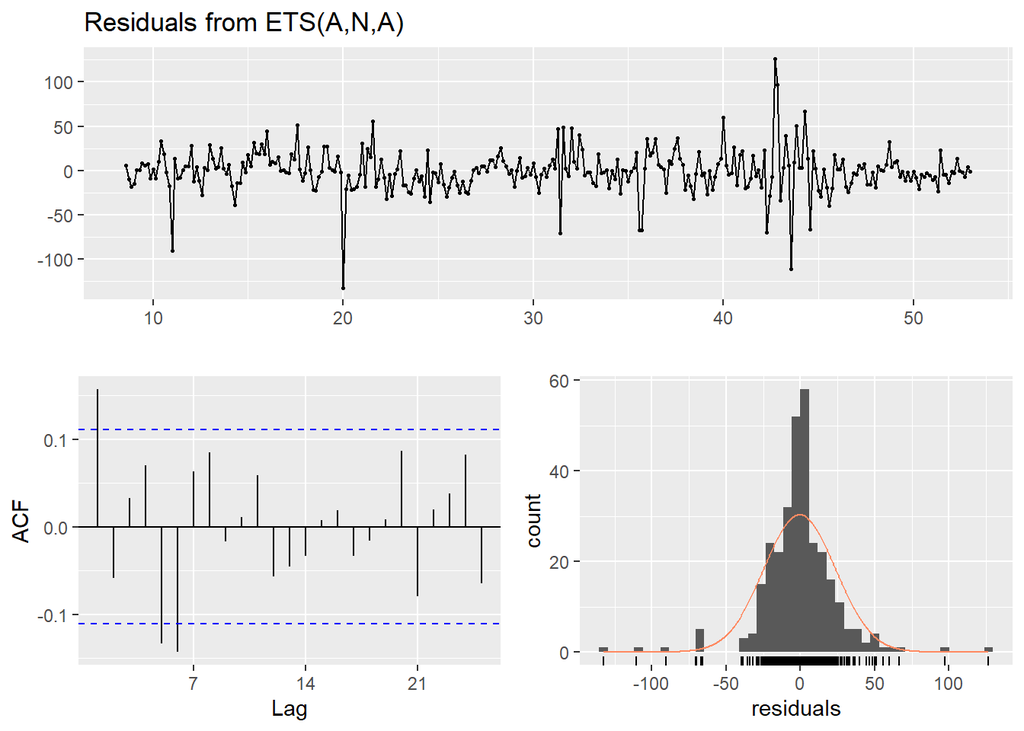

```
##
##  Ljung-Box test
##
## data:  Residuals from ETS(A,N,A)
## Q* = 29.858, df = 5, p-value = 1.573e-05
##
## Model df: 9.   Total lags used: 14
```

```r
checkresiduals(fc_atm1_ets)
```

#### Use ARIMA

#### Now use ARIMA arima auto function to select the most appropriate model.

```r
atm1_lambda <- BoxCox.lambda(atm1)
fc_arima_atm1 <- auto.arima(atm1)
summary(fc_arima_atm1)
```

```
## Series: atm1
## ARIMA(1,0,0)(2,1,0)[7]
##
## Coefficients:
##          ar1     sar1     sar2
##       0.1511  -0.4698  -0.2048
## s.e.  0.0535   0.0517   0.0514
##
## sigma^2 estimated as 606.7:  log likelihood=-1641.05
## AIC=3290.11   AICc=3290.22   BIC=3305.63
##
## Training set error measures:
##                       ME     RMSE      MAE       MPE    MAPE      MASE
## Training set -0.08937144 24.28804 15.37384 -98.72979 115.434 0.8697514
##                     ACF1
## Training set 0.009201474
```

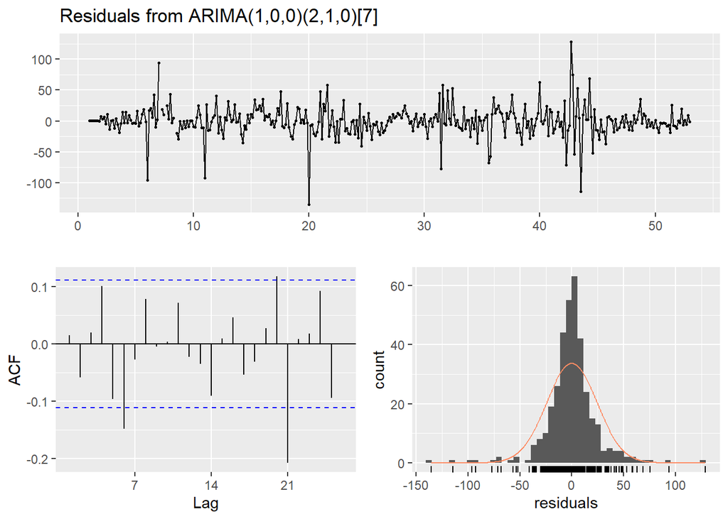

```
##
##  Ljung-Box test
##
## data:  Residuals from ARIMA(1,0,0)(2,1,0)[7]
## Q* = 18.297, df = 11, p-value = 0.07494
##
## Model df: 3.   Total lags used: 14
```

```r
checkresiduals(fc_arima_atm1)
```

#### Create model for 2nd ATM

#### Use ETS

```r
fc_atm2_ets <- ets(atm2)
```

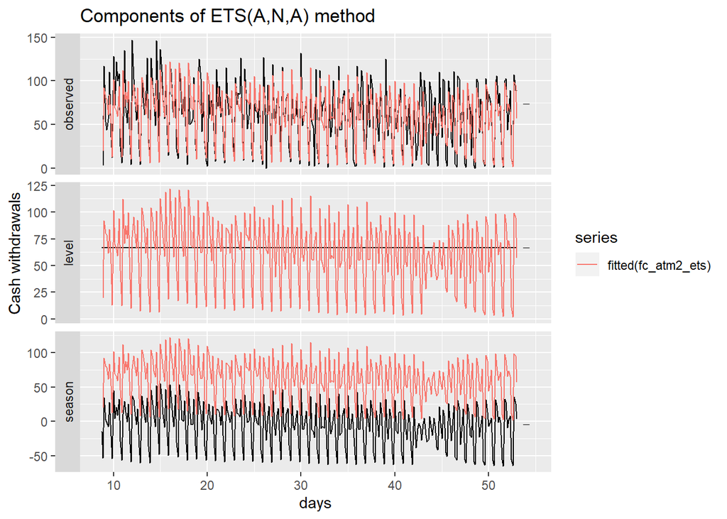

```r
autoplot(fc_atm2_ets) +
  autolayer(fitted(fc_atm2_ets)) +
  ylab("Cash withdrawals") + xlab("days")
```

#### Check summary of ets method applied to ATM2

```r
summary(fc_atm2_ets)
```

```
## ETS(A,N,A)
##
## Call:
##  ets(y = atm2)
##
##   Smoothing parameters:
##     alpha = 1e-04
##     gamma = 0.3912
##
##   Initial states:
##     l = 66.8249
##     s = -15.0241 17.0779 -5.3735 12.1217 13.3698 25.1207
##            -47.2925
##
##   sigma:  25.0036
##
##      AIC     AICc      BIC
## 3784.996 3785.732 3822.362
##
## Training set error measures:
##                      ME     RMSE      MAE  MPE MAPE      MASE        ACF1
## Training set -0.3870142 24.63795 17.33529 -Inf  Inf 0.8774794 0.006439035
```

#### Check for residuals

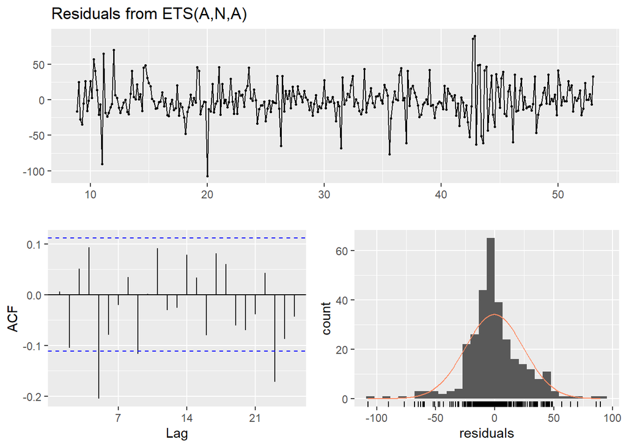

```
##
##  Ljung-Box test
##
## data:  Residuals from ETS(A,N,A)
## Q* = 32.511, df = 5, p-value = 4.705e-06
##
## Model df: 9.   Total lags used: 14
```

```r
checkresiduals(fc_atm2_ets)
```

#### Use ARIMA for ATM2

#### Now use ARIMA arima auto function to select the most appropriate model.

```r
atm2_lambda <- BoxCox.lambda(atm2)
fc_arima_atm2 <- auto.arima(atm2)
summary(fc_arima_atm2)
```

```
## Series: atm2
## ARIMA(0,0,0)(2,1,0)[7]
##
## Coefficients:
##          sar1     sar2
##       -0.5747  -0.1766
## s.e.   0.0521   0.0518
##
## sigma^2 estimated as 652.8:  log likelihood=-1659.31
## AIC=3324.61   AICc=3324.68   BIC=3336.26
##
## Training set error measures:
##                      ME     RMSE      MAE  MPE MAPE      MASE       ACF1
## Training set -0.1179362 25.23195 17.27829 -Inf  Inf 0.8434248 0.01502367
```

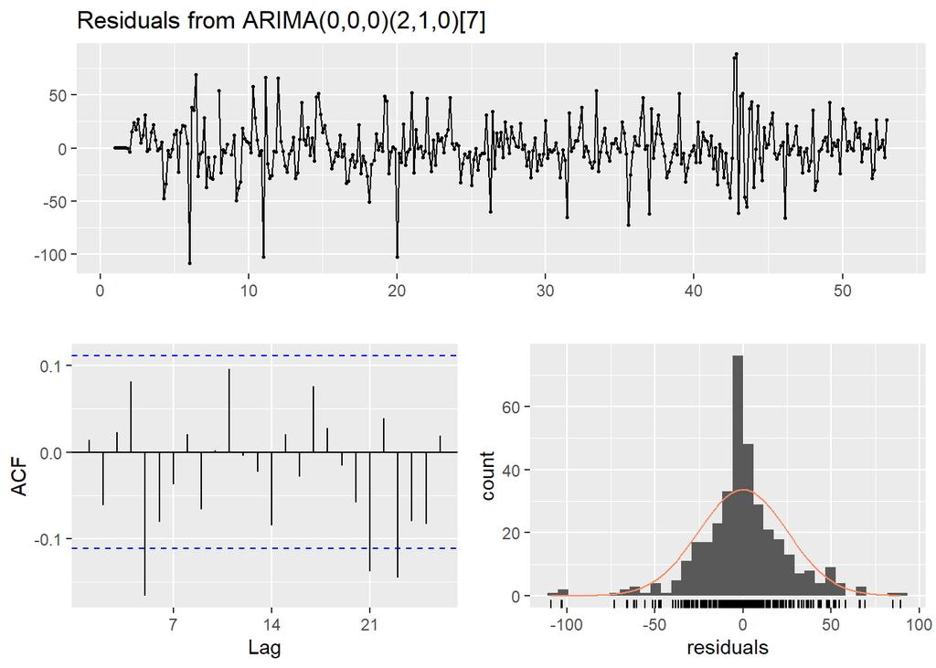

```
##
##  Ljung-Box test
##
## data:  Residuals from ARIMA(0,0,0)(2,1,0)[7]
## Q* = 28.213, df = 12, p-value = 0.005149
##
## Model df: 2.   Total lags used: 14
```

```r
checkresiduals(fc_arima_atm2)
```

#### Create Model for 3rd ATM

> ATM3 has only 3 values which are present only in the last 3 days. It will be hard to forecast with the limited amount of data that we have. In this case we can use the mean value.

#### Create model for 4th ATM

#### Use ETS

```r
fc_atm4_ets <- ets(atm4)
```

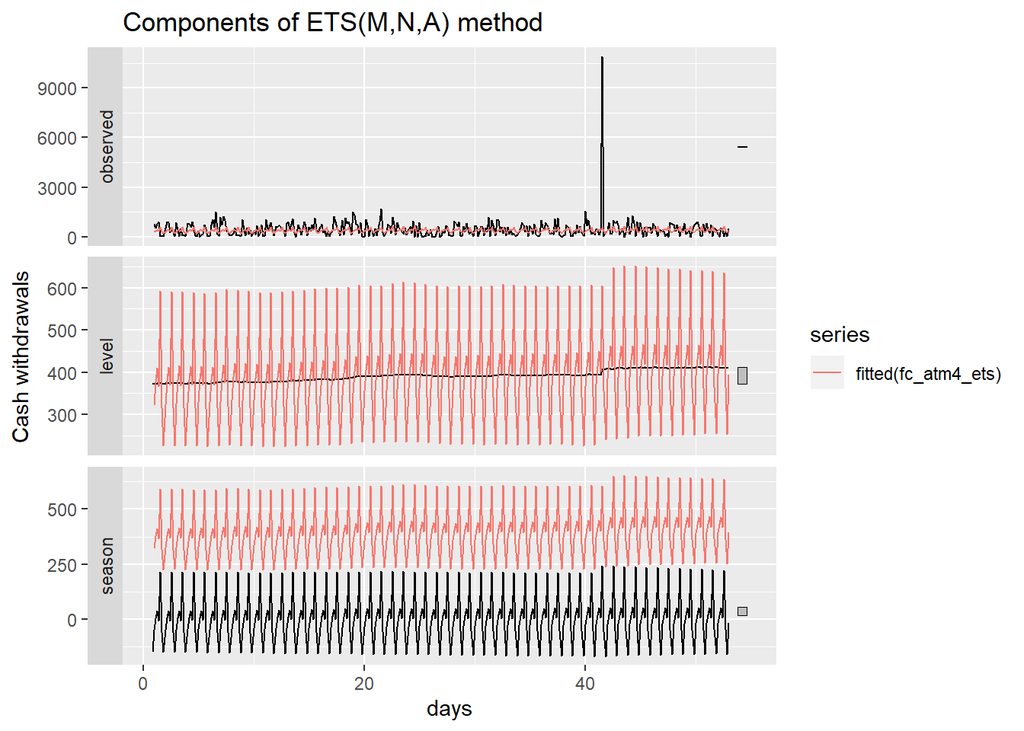

```r
autoplot(fc_atm4_ets) +
  autolayer(fitted(fc_atm4_ets)) +
  ylab("Cash withdrawals") + xlab("days")
```

#### Check summary of ets method applied to ATM4

```r
summary(fc_atm4_ets)
```

```
## ETS(M,N,A)
##
## Call:
##  ets(y = atm4)
##
##   Smoothing parameters:
##     alpha = 0.0013
##     gamma = 0.003
##
##   Initial states:
##     l = 372.4108
##     s = -146.6545 -57.0431 217.4408 -6.2437 37.4918 5.355
##            -50.3463
##
##   sigma:  1.2874
##
##      AIC     AICc      BIC
## 6690.624 6691.246 6729.623
##
## Training set error measures:
##                    ME     RMSE      MAE       MPE     MAPE      MASE
## Training set 77.03608 645.1182 312.3148 -510.4324 551.5781 0.7771069
##                     ACF1
## Training set -0.01055406
```

#### Check for residuals

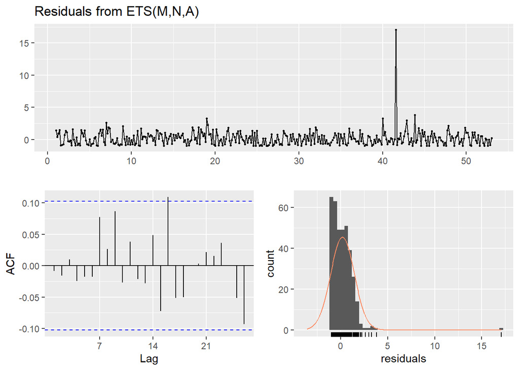

```
##
##  Ljung-Box test
##
## data:  Residuals from ETS(M,N,A)
## Q* = 8.1066, df = 5, p-value = 0.1505
##
## Model df: 9.   Total lags used: 14
```

```r
checkresiduals(fc_atm4_ets)
```

#### Use ARIMA for ATM4

#### Now use ARIMA arima auto function to select the most appropriate model.

```r
atm4_lambda <- BoxCox.lambda(atm4)
fc_arima_atm4 <- auto.arima(atm4)
summary(fc_arima_atm4)
```

```
## Series: atm4
## ARIMA(0,0,0) with non-zero mean
##
## Coefficients:
##           mean
##       474.0433
## s.e.   34.0248
##
## sigma^2 estimated as 423718:  log likelihood=-2882.03
## AIC=5768.06   AICc=5768.1   BIC=5775.86
##
## Training set error measures:
##                         ME     RMSE      MAE       MPE     MAPE      MASE
## Training set -1.514697e-10 650.0437 323.6001 -616.5219 646.8627 0.8051872
##                      ACF1
## Training set -0.009358419
```

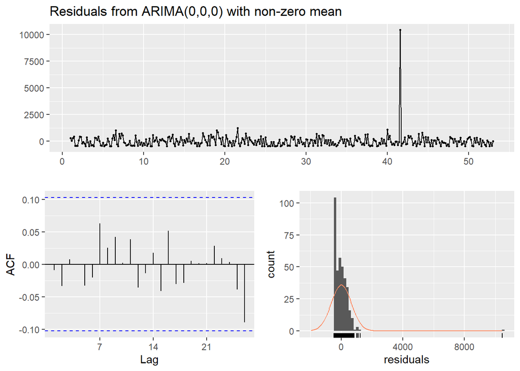

```
##
##  Ljung-Box test
##
## data:  Residuals from ARIMA(0,0,0) with non-zero mean
## Q* = 4.6668, df = 13, p-value = 0.9818
##
## Model df: 1.   Total lags used: 14
```

```r
checkresiduals(fc_arima_atm4)
```

#### Fit Model

```r
atm1_fit<-Arima(atm1, order = c(1, 0, 0), seasonal = c(2, 1, 0), lambda = atm1_lambda)
atm1_forecast<-forecast(atm1_fit, 31, level = 95)
atm2_fit<-Arima(atm2, order = c(1, 0, 0), seasonal = c(2, 1, 0), lambda = atm2_lambda)
atm2_forecast<-forecast(atm2_fit, 31, level = 95)
atm3_forecast<-meanf(atm3, 31, level = 95)
atm4_fit<-Arima(atm4, order = c(0, 0, 0), lambda = atm4_lambda)
atm4_forecast<-forecast(atm4_fit, 31, level = 95)
```

#### Output

#### Export the results of ATM1, ATM2, ATM3 and ATM4 in to a single CSV file.

```r
data_frame(DATE = rep(max(df$DATE) + 1:31, 4), ATM = rep(names(df)[-1], each = 31), Cash = c(atm1_forecast$mean, atm2_forecast$mean, atm3_forecast$mean, atm4_forecast$mean)) %>%
  write_csv("DATA624_ATM_PREDICTION.csv")
```

### Part B – Forecasting Power :

### Part B consists of a simple dataset of residential power usage for January 1998 until December 2013. Your assignment is to model these data and a monthly forecast for 2014. The data is given in a single file. The variable ‘KWH’ is power consumption in Kilowatt hours, the rest is straight forward. Add this to your existing files above.

#### Loading Data and verifying

```r
power_df <- read_excel("ResidentialCustomerForecastLoad-624.xlsx")
power_df <- ts(power_df[, "KWH"], start = c(1998, 1), frequency = 12)
```

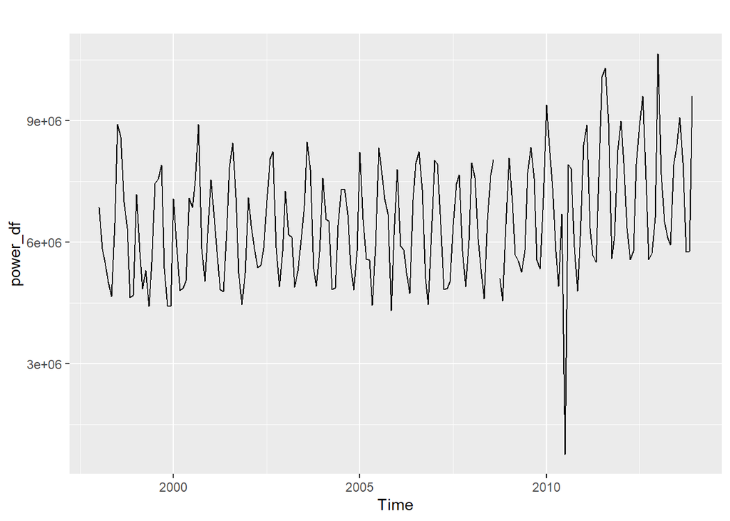

```r
autoplot(power_df)
```

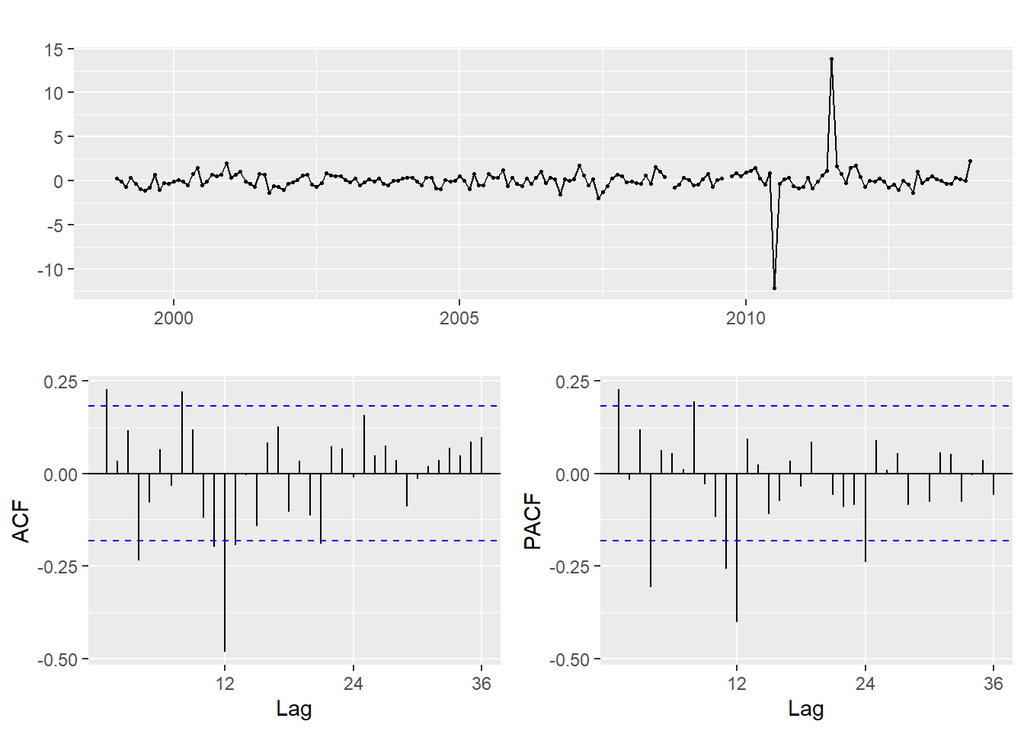

```r
power_lambda <- BoxCox.lambda(power_df)
power_trans <- BoxCox(power_df, power_lambda)
ggtsdisplay(diff(power_trans, 12))
```

#### Ue ARIMA

#### Now use ARIMA arima auto function to select the most appropriate model

```r
fc_arima_power <- auto.arima(power_trans)
summary(fc_arima_power)
```

```
## Series: power_trans
## ARIMA(2,1,1)(0,0,2)[12]
##
## Coefficients:
##          ar1      ar2      ma1    sma1    sma2
##       0.2593  -0.1585  -0.9752  0.1980  0.2061
## s.e.  0.0743   0.0769   0.0171  0.0816  0.0674
##
## sigma^2 estimated as 1.7:  log likelihood=-319.45
## AIC=650.9   AICc=651.36   BIC=670.41
##
## Training set error measures:
##                     ME     RMSE      MAE      MPE     MAPE     MASE        ACF1
## Training set 0.1024691 1.283068 0.796867 0.134273 1.878771 1.160183 -0.03283777
```

#### With Ljung box we will test the residuals

```r
Box.test(resid(fc_arima_power), type = "L", fitdf = 3, lag = 12)
```

```
##
##  Box-Ljung test
##
## data:  resid(fc_arima_power)
## X-squared = 20.847, df = 9, p-value = 0.01335
```

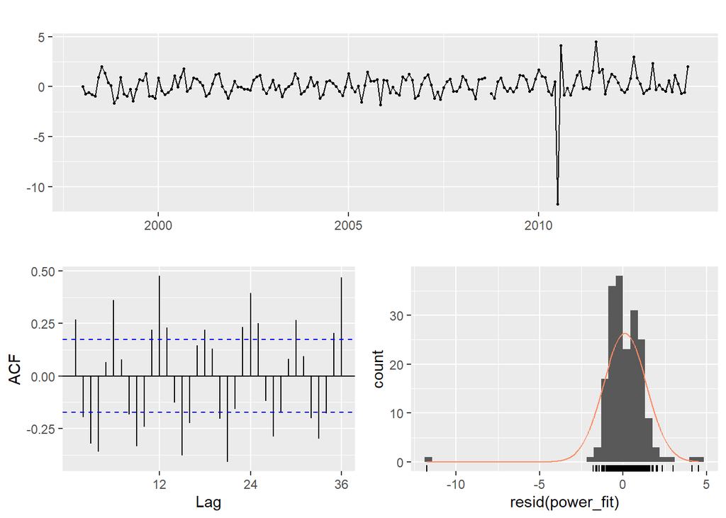

```r
power_fit <- Arima(power_df, order = c(2, 1, 1), seasonal = c(0, 0, 2), lambda = power_lambda)
ggtsdisplay(resid(power_fit), plot.type = "histogram")
```

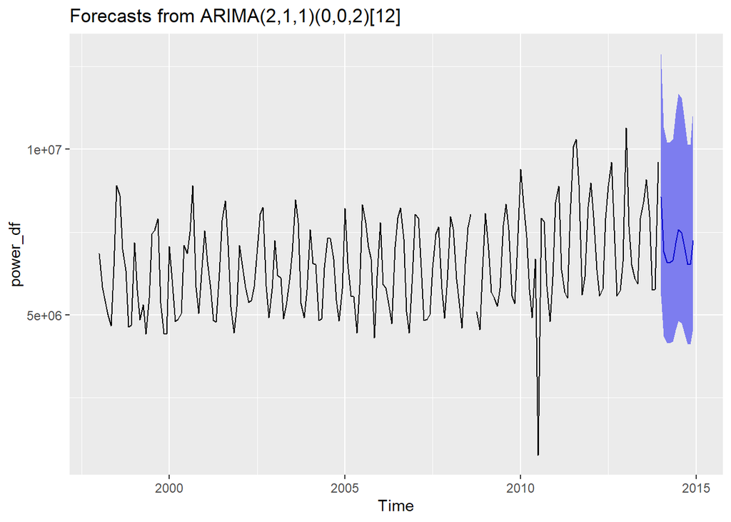

```r
power_forecast <- forecast(power_fit, 12, level = 95)
autoplot(power_forecast)
```

#### Output

#### Write the forecasted data to a seperate file

```r
data_frame(`YYYY-MMM` = paste0(2014, "-", month.abb), KWH = power_forecast$mean) %>%
  write_csv("DATA624_POWER_FORECASTING.csv")
```

### Part C – Waterflow_Pipe :

### Part C consists of two data sets. These are simple 2 columns sets, however they have different time stamps. Your optional assignment is to time-base sequence the data and aggregate based on hour (example of what this looks like, follows). Note for multiple recordings within an hour, take the mean. Then to determine if the data is stationary and can it be forecast. If so, provide a week forward forecast and present results via Rpubs and .rmd and the forecast in an Excel readable file.

#### Loading data and verifying

```r
water_1 = read_excel("Waterflow_Pipe1.xlsx",col_types =c("date", "numeric"))
water_2 = read_excel("Waterflow_Pipe2.xlsx",col_types =c("date", "numeric"))
```

```r
colnames(water_1)= c("Date_time","WaterFlow")
colnames(water_2)= c("Date_Time","WaterFlow")
```

#### As specified in the question, lets try to seperate date and hour reading and combine them to make a single dataset. Additionally group by data and aggregate.

```r
Water_df= water_1 %>% mutate(Date_Time = lubridate::round_date(Date_time,"hour") ) %>% select(Date_Time,WaterFlow) %>% bind_rows(water_2) %>% group_by(Date_Time) %>% summarize(WaterFlowF = mean(WaterFlow, na.rm = T))
```

#### Specify the frequency as 24

```r
Water_ts = ts(Water_df$WaterFlowF,frequency = 24)
```

#### Use ETS

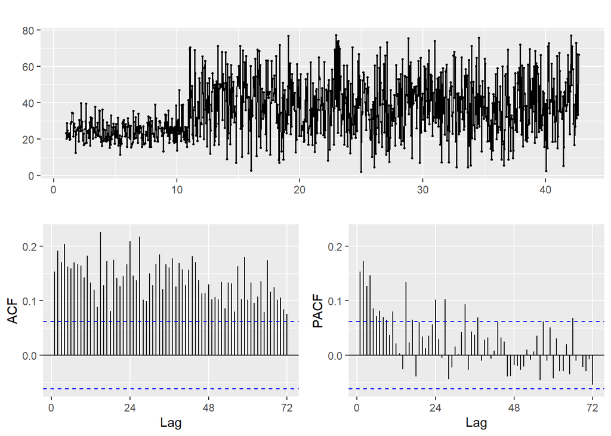

```r
ggtsdisplay(Water_ts)
```

```r
Water_Model1 = ets(Water_ts,lambda=BoxCox.lambda(Water_ts))
```

#### Check summary of ets method

```r
summary(Water_Model1)
```

```
## ETS(A,N,N)
##
## Call:
##  ets(y = Water_ts, lambda = BoxCox.lambda(Water_ts))
##
##   Box-Cox transformation: lambda= -0.8244
##
##   Smoothing parameters:
##     alpha = 0.0119
##
##   Initial states:
##     l = 1.1247
##
##   sigma:  0.047
##
##      AIC     AICc      BIC
## 798.1980 798.2221 812.9243
##
## Training set error measures:
##                    ME     RMSE      MAE       MPE     MAPE     MASE       ACF1
## Training set 7.738182 16.76823 12.74726 -1.625442 42.41892 0.849401 0.05613023
```

#### Check for residuals

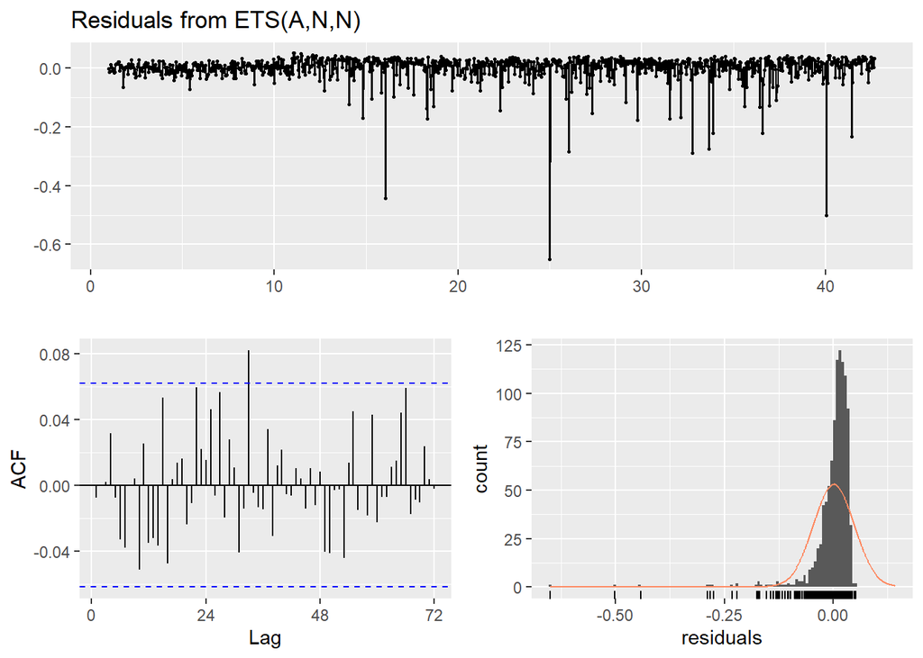

```
##
##  Ljung-Box test
##
## data:  Residuals from ETS(A,N,N)
## Q* = 41.298, df = 46, p-value = 0.6692
##
## Model df: 2.   Total lags used: 48
```

```r
checkresiduals(Water_Model1)
```

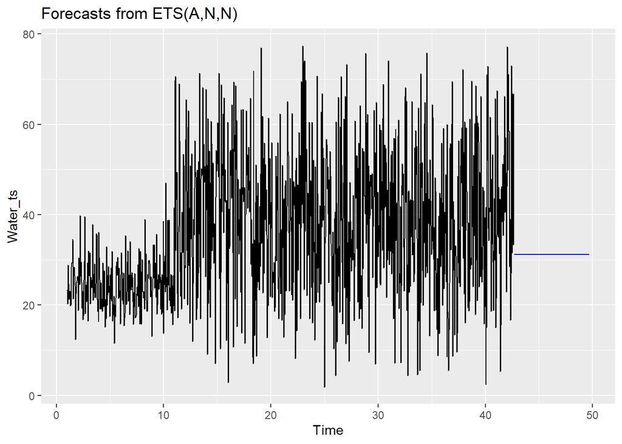

```r
autoplot(forecast(Water_Model1, 168, level = 95))
```

```r
Water_Model1_Forecast = forecast(Water_Model1, 168, level=95)
```

#### Use ARIMA

#### Now use ARIMA arima auto function to select the most appropriate model.

```r
Water_Model2 =auto.arima(Water_ts,lambda=BoxCox.lambda(Water_ts))
```

#### Check summary of ARIMA

```r
summary(Water_Model2)
```

```
## Series: Water_ts
## ARIMA(3,1,3)
## Box Cox transformation: lambda= -0.8243695
##
## Coefficients:
##           ar1      ar2      ar3      ma1     ma2      ma3
##       -0.4049  -0.9688  -0.0339  -0.5872  0.5673  -0.9475
## s.e.   0.0439   0.0255   0.0329   0.0309  0.0345   0.0236
##
## sigma^2 estimated as 0.002199:  log likelihood=1642.1
## AIC=-3270.2   AICc=-3270.09   BIC=-3235.85
##
## Training set error measures:
##                    ME     RMSE      MAE       MPE     MAPE      MASE       ACF1
## Training set 7.529514 16.72952 12.64518 -1.560004 41.71755 0.8425988 0.05232296
```

#### Check for residuals

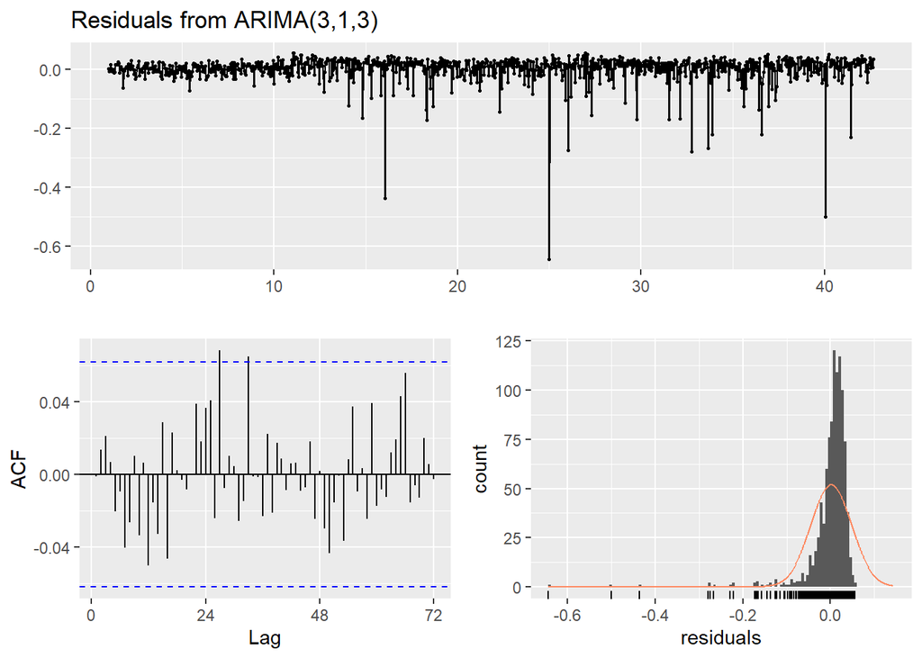

```
##
##  Ljung-Box test
##
## data:  Residuals from ARIMA(3,1,3)
## Q* = 31.449, df = 42, p-value = 0.883
##
## Model df: 6.   Total lags used: 48
```

```r
checkresiduals(Water_Model2)
```

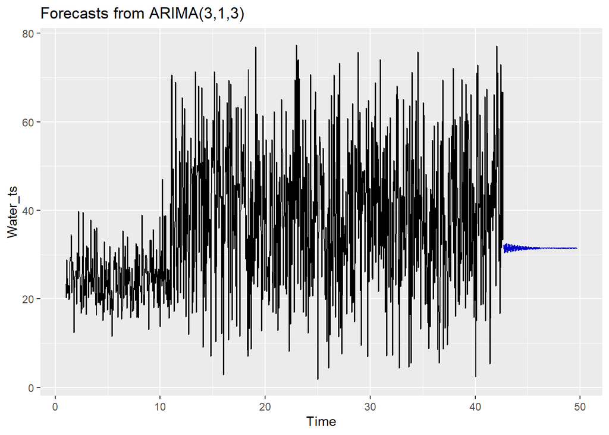

```r
Water_Model2_Forecast = forecast(Water_Model2, 168, level=95)

autoplot(forecast(Water_Model2, 168, level = 95))
```

#### Wtire forecasted data to file

```r
Water_csv= data_frame(Date_Time = max(Water_df$Date_Time) + lubridate::hours(1:168),
           WaterFlowF = as.numeric( Water_Model2_Forecast$mean) )

write.csv(Water_csv,"DATA624_WATERPIPE_FORECAST.csv")
```